# Data Wrangling Practice

Joe Eldredge | jwe2n@virginia.edu

# Purpose of Exercise

In this exercise I go over some of the fundamental commands from tidyverse library that I use all the time to “tidy” datasets or “wrangle”. You can see variants of this used in pretty much every work on my portfolio. The example comes from Mike Chappele’s Data Wrangling in R LinkedIn course.

The first is just regarding reading in datasets.

```r
library(tidyverse)
library(lubridate)
library(stringr)
coal<-read_csv('http://594442.youcanlearnit.net/coal.csv',skip=2)
water<-read_csv('http://594442.youcanlearnit.net/austinwater.csv')

#glimpse(coal)
#glimpse(water) #there are a lot of columns in this tibble that we won't need
summary(coal) #we find that the data types are all wrong, we expected numeric data
```

```
#>       X1                1980               1981               1982
#>  Length:232         Length:232         Length:232         Length:232
#>  Class :character   Class :character   Class :character   Class :character
#>  Mode  :character   Mode  :character   Mode  :character   Mode  :character
#>      1983               1984               1985               1986
#>  Length:232         Length:232         Length:232         Length:232
#>  Class :character   Class :character   Class :character   Class :character
#>  Mode  :character   Mode  :character   Mode  :character   Mode  :character
#>      1987               1988               1989               1990
#>  Length:232         Length:232         Length:232         Length:232
#>  Class :character   Class :character   Class :character   Class :character
#>  Mode  :character   Mode  :character   Mode  :character   Mode  :character
#>      1991               1992               1993               1994
#>  Length:232         Length:232         Length:232         Length:232
#>  Class :character   Class :character   Class :character   Class :character
#>  Mode  :character   Mode  :character   Mode  :character   Mode  :character
#>      1995               1996               1997               1998
#>  Length:232         Length:232         Length:232         Length:232
#>  Class :character   Class :character   Class :character   Class :character
#>  Mode  :character   Mode  :character   Mode  :character   Mode  :character
#>      1999               2000               2001               2002
#>  Length:232         Length:232         Length:232         Length:232
#>  Class :character   Class :character   Class :character   Class :character
#>  Mode  :character   Mode  :character   Mode  :character   Mode  :character
#>      2003               2004               2005               2006
#>  Length:232         Length:232         Length:232         Length:232
#>  Class :character   Class :character   Class :character   Class :character
#>  Mode  :character   Mode  :character   Mode  :character   Mode  :character
#>      2007               2008               2009
#>  Length:232         Length:232         Length:232
#>  Class :character   Class :character   Class :character
#>  Mode  :character   Mode  :character   Mode  :character
```

## Transforming from Wide to Long Dataset

We are going to transform the coal tibble using gather, which gathers columns into key-value pairs:

[output not shown]

Now I need to transform the year to an integer, as I can see from above it is a character.

```r
coal_long$year <- as.integer(coal_long$year)
coal_long$coal_consumption <- as.numeric(coal_long$coal_consumption)
summary(coal_long)
```

```
#>     region               year      coal_consumption
#>  Length:6960        Min.   :1980   Min.   : -0.0003
#>  Class :character   1st Qu.:1987   1st Qu.:  0.0000
#>  Mode  :character   Median :1994   Median :  0.0002
#>                     Mean   :1994   Mean   :  1.3256
#>                     3rd Qu.:2002   3rd Qu.:  0.0773
#>                     Max.   :2009   Max.   :138.8298
#>                                    NA's   :517
```

```r
unique(coal_long$region) #gives me names of all the countries
```

```
#>   [1] "North America"                     "Bermuda"
#>   [3] "Canada"                            "Greenland"
#>   [5] "Mexico"                            "Saint Pierre and Miquelon"
#>   [7] "United States"                     "Central & South America"
#>   [9] "Antarctica"                        "Antigua and Barbuda"
#>  [11] "Argentina"                         "Aruba"
#>  [13] "Bahamas, The"                      "Barbados"
#>  [15] "Belize"                            "Bolivia"
#>  [17] "Brazil"                            "Cayman Islands"
#>  [19] "Chile"                             "Colombia"
#>  [21] "Costa Rica"                        "Cuba"
#>  [23] "Dominica"                          "Dominican Republic"
#>  [25] "Ecuador"                           "El Salvador"
#>  [27] "Falkland Islands (Islas Malvinas)" "French Guiana"
#>  [29] "Grenada"                           "Guadeloupe"
```

[output cut: 101 more lines]

```r
noncountries<-c("North America","Central & South AMerica", "Antartica", "Europe", "Eurasia", "Middle East", "Africa", "Asia & Oceania", "World")
matches <- which(!is.na(match(coal_long$region,noncountries))) #I want to see values for "true" whenever a continent was present;
```

```r
coal_country <- coal_long[-matches,]
coal_region <- coal_long[matches,]
unique(coal_country$region)
```

```
#>   [1] "Bermuda"                           "Canada"
#>   [3] "Greenland"                         "Mexico"
#>   [5] "Saint Pierre and Miquelon"         "United States"
#>   [7] "Central & South America"           "Antarctica"
#>   [9] "Antigua and Barbuda"               "Argentina"
#>  [11] "Aruba"                             "Bahamas, The"
#>  [13] "Barbados"                          "Belize"
#>  [15] "Bolivia"                           "Brazil"
#>  [17] "Cayman Islands"                    "Chile"
#>  [19] "Colombia"                          "Costa Rica"
#>  [21] "Cuba"                              "Dominica"
#>  [23] "Dominican Republic"                "Ecuador"
#>  [25] "El Salvador"                       "Falkland Islands (Islas Malvinas)"
#>  [27] "French Guiana"                     "Grenada"
#>  [29] "Guadeloupe"                        "Guatemala"
```

[output cut: 98 more lines]

```r
unique(coal_region$region)
```

```
#> [1] "North America"  "Europe"         "Eurasia"        "Middle East"
#> [5] "Africa"         "Asia & Oceania" "World"
```

Now we can visualize data.

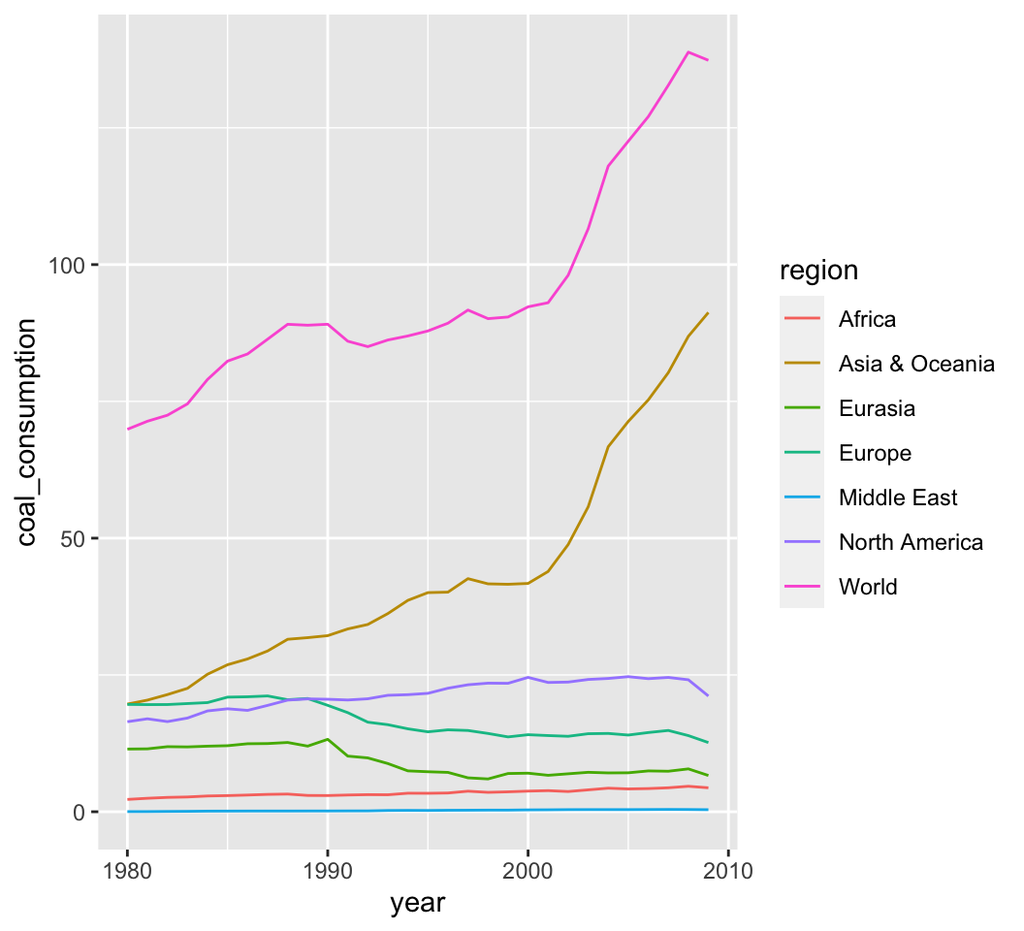

```r
ggplot(data=coal_region,mapping=aes(x=year,y=coal_consumption)) +
geom_line(mapping=aes(color=region))
```

We create a new tibble with just the data we are interested from the Austin water quality dataset.

```r
waternew<-tibble('siteName'=water$SITE_NAME,
              'siteType'=water$SITE_TYPE,
              'sampleTime'=water$SAMPLE_DATE,
              'parameterType'=water$PARAM_TYPE,
              'parameter'=water$PARAMETER,
              'result'=water$RESULT,
              'unit'=water$UNIT)
#glimpse(waternew)
#unique(waternew[which(str_detect(waternew$parameter,'PH')),]$parameter) #still too many unique types
unique(waternew$parameterType) #Conventionals seems like it might have normal drinking water
```

```
#>  [1] "Benthic Macroinvertebrates"
#>  [2] "Fish"
#>  [3] "Grain Size/Substrate Characterization"
#>  [4] "Habitat Evaluation"
#>  [5] "Physicals"
#>  [6] "Salamanders"
#>  [7] "Spatial"
#>  [8] "Temporal"
#>  [9] "Flow/Rainfall"
#> [10] "Alkalinity/Hardness/pH"
#> [11] "Conventionals"
#> [12] "Metals"
#> [13] "Nutrients"
#> [14] "Oxygen"
#> [15] "Sample Collection Methods"
```

[output cut: 80 more lines]

```r
filtered_water <-subset(waternew,(parameterType=='Alkalinity/Hardness/pH')|parameterType=='Conventionals')
#glimpse(filtered_water)
unique(filtered_water$parameter)
```

```
#>  [1] "PH"
#>  [2] "WATER TEMPERATURE"
#>  [3] "ALKALINITY (AS CACO3)"
#>  [4] "ALKALINITY BICARBONATE (AS CACO3)"
#>  [5] "ALKALINITY CARBONATE (AS CACO3)"
#>  [6] "ALKALINITY HYDROXIDE (AS CACO3)"
#>  [7] "ALKALINITY PHENOLPHTHALEIN"
#>  [8] "HARDNESS (AS CACO3)"
#>  [9] "24-HOUR AVG PH"
#> [10] "24-HOUR MAX PH"
#> [11] "24-HOUR MIN PH"
#> [12] "NUMBER OF PH MEASUREMENTS IN 24-HOURS"
#> [13] "OXIDATION-REDUCTION_POTENTIAL"
#> [14] "BICARBONATE (AS HCO3)"
#> [15] "CALCIUM+MAGNESIUM HARDNESS (AS CACO3)"
#> [16] "CARBONATE (AS CO3)"
```

```r
filtered_water<-subset(filtered_water, (parameter=='PH')|(parameter=='WATER TEMPERATURE'))
glimpse(filtered_water) #down to just observatoins that are most relevant
```

```
#> Rows: 51,797
#> Columns: 7
#> $ siteName      <chr> "North Branch of Sycamore Creek @ Foster Ranch Rd", "No…
#> $ siteType      <chr> "Stream", "Stream", "Spring", "Spring", "Stream", "Stre…
#> $ sampleTime    <chr> "01/21/2015 12:00:00 PM", "01/21/2015 12:00:00 PM", "01…
#> $ parameterType <chr> "Alkalinity/Hardness/pH", "Conventionals", "Alkalinity/…
#> $ parameter     <chr> "PH", "WATER TEMPERATURE", "PH", "WATER TEMPERATURE", "…
#> $ result        <dbl> 8.35, 11.73, 7.82, 18.29, 8.15, 8.09, 8.47, 8.12, 8.61,…
#> $ unit          <chr> "Standard units", "Deg. Celsius", "Standard units", "De…
```

```r
filtered_water$siteType <- as.factor(filtered_water$siteType)
filtered_water$unit<-as.factor(filtered_water$unit)
filtered_water$parameter<-as.factor(filtered_water$parameter)
filtered_water$sampleTime<-mdy_hms(filtered_water$sampleTime) #this is a function that gives month/date/time format; needed to convert from string
```

Summarizing the filtered water gives me some interesting information.The first is that there is a measurement of “feet”. A reasonable assumption is that someone typed “Ft” instead of “F” on a form (fat finger error).

```r
summary(filtered_water)
```

```
#>    siteName                                      siteType
#>  Length:51797       Stream                           :24091
#>  Class :character   Lake                             :16852
#>  Mode  :character   Spring                           : 7248
#>                     Well                             : 1607
#>                     Soil                             : 1591
#>                     Non-spatial or Protected Location:  218
#>                     (Other)                          :  190
#>    sampleTime                  parameterType                  parameter
#>  Min.   :1986-05-01 13:35:00   Length:51797       PH               :25624
#>  1st Qu.:1997-05-29 09:31:00   Class :character   WATER TEMPERATURE:26173
#>  Median :2002-03-12 09:30:00   Mode  :character
#>  Mean   :2003-06-19 12:12:39
#>  3rd Qu.:2009-12-16 11:40:00
#>  Max.   :2017-02-09 14:00:00
#>
#>      result                       unit
#>  Min.   :      0.1   Deg. Celsius   :26121
#>  1st Qu.:      7.7   Deg. Fahrenheit:   47
#>  Median :      9.8   Feet           :    1
#>  Mean   :     45.7   MG/L           :    7
#>  3rd Qu.:     21.1   Standard units :25621
#>  Max.   :1112340.0
#>  NA's   :1
```

```r
subset(filtered_water,unit=='Feet') #observation 10520 to be a water temperature measure, but the unit is "Feet";
```

```
#> # A tibble: 1 x 7
#>   siteName   siteType sampleTime          parameterType parameter   result unit
#>   <chr>      <fct>    <dttm>              <chr>         <fct>        <dbl> <fct>
#> 1 Lanier We… Well     2012-09-25 10:25:00 Conventionals WATER TEMP…   78.9 Feet
```

```r
convert<-which(filtered_water$unit=='Feet')
filtered_water$unit[convert]<- 'Deg. Farenheit' #replace that bad unit type with Deg. Fahrenheit
convert2<-which((filtered_water$unit=='MG/L' & filtered_water$parameter=='PH'))
filtered_water$unit[convert2]<-'Standard Units' #replace MG/L unit with 'Standard units'
convert3<-which((filtered_water$unit=='MG/L' & filtered_water$result>'70')) #restricting this to cases where the unit is probably fahrenheit
filtered_water$unit[convert3]<-'Deg. Farenheit' #these look like either Fahrenheit or Celsius, so we change to 'Standard units'
convert4<-which(filtered_water$unit=='MG/L')
filtered_water$unit[convert4]<-'Deg. Celsius'
summary(filtered_water)
```

```
#>    siteName                                      siteType
#>  Length:51797       Stream                           :24091
#>  Class :character   Lake                             :16852
#>  Mode  :character   Spring                           : 7248
#>                     Well                             : 1607
#>                     Soil                             : 1591
#>                     Non-spatial or Protected Location:  218
#>                     (Other)                          :  190
#>    sampleTime                  parameterType                  parameter
#>  Min.   :1986-05-01 13:35:00   Length:51797       PH               :25624
#>  1st Qu.:1997-05-29 09:31:00   Class :character   WATER TEMPERATURE:26173
#>  Median :2002-03-12 09:30:00   Mode  :character
#>  Mean   :2003-06-19 12:12:39
#>  3rd Qu.:2009-12-16 11:40:00
#>  Max.   :2017-02-09 14:00:00
#>
#>      result                       unit
#>  Min.   :      0.1   Deg. Celsius   :26124
#>  1st Qu.:      7.7   Deg. Fahrenheit:   47
#>  Median :      9.8   Feet           :    0
#>  Mean   :     45.7   MG/L           :    0
#>  3rd Qu.:     21.1   Standard units :25621
#>  Max.   :1112340.0   NA's           :    5
#>  NA's   :1
```

```r
#ggplot(filtered_water,mapping=aes(x=sampleTime,y=result))+geom_point() #this shows an outlier over 1 million degrees
remove<-which(filtered_water$result>1000 | is.na(filtered_water$unit) | is.na(filtered_water$result)) #removing ridiculously high numbers; probably entry errors
filtered_water<-filtered_water[-remove,]
summary(filtered_water)
```

```
#>    siteName                                      siteType
#>  Length:51717       Stream                           :24089
#>  Class :character   Lake                             :16852
#>  Mode  :character   Spring                           : 7245
#>                     Soil                             : 1591
#>                     Well                             : 1532
#>                     Non-spatial or Protected Location:  218
#>                     (Other)                          :  190
#>    sampleTime                  parameterType                  parameter
#>  Min.   :1986-05-01 13:35:00   Length:51717       PH               :25620
#>  1st Qu.:1997-05-19 14:00:00   Class :character   WATER TEMPERATURE:26097
#>  Median :2002-03-06 10:45:00   Mode  :character
#>  Mean   :2003-06-14 12:47:10
#>  3rd Qu.:2009-12-14 11:30:00
#>  Max.   :2017-02-09 14:00:00
#>
#>      result                    unit
#>  Min.   : 0.114   Deg. Celsius   :26050
#>  1st Qu.: 7.700   Deg. Fahrenheit:   47
#>  Median : 9.600   Feet           :    0
#>  Mean   :14.239   MG/L           :    0
#>  3rd Qu.:21.080   Standard units :25620
#>  Max.   :78.920
#>
```

```r
filtered_water<-filtered_water[-remove,]
```

We now recheck for outliers using the boxplot function. The data looks much more reasonable with only three units.

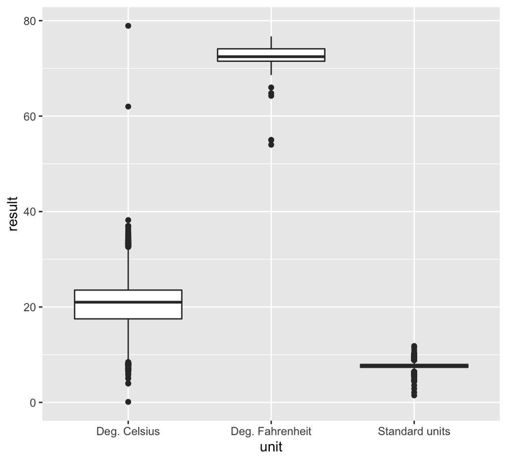

```r
ggplot(data=filtered_water,mapping=aes(x=unit,y=result))+geom_boxplot()
```

```r
convert5<-which(filtered_water$result>60 & filtered_water$unit=='Deg. Celsisus')
filtered_water$unit[convert5]
```

```
#> factor(0)
#> Levels: Deg. Celsius Deg. Fahrenheit Feet MG/L Standard units
```

```r
fahrenheit<-which(filtered_water$unit=='Deg. Fahrenheit')
filtered_water$result[fahrenheit]<-(filtered_water$result[fahrenheit]-32)*(5.0/9.0) #we update the resulting fahrenheit temperature to celsius using a conversion formula
filtered_water$unit[fahrenheit]<-'Deg. Celsius' #now we convert the units to Deg. Celsius to reflect the updated figures
filtered_water$unit<-droplevels(filtered_water$unit) #we drop the factor levels
summary(filtered_water)
```

```
#>    siteName                                      siteType
#>  Length:51637       Stream                           :24071
#>  Class :character   Lake                             :16848
#>  Mode  :character   Spring                           : 7230
#>                     Soil                             : 1591
#>                     Well                             : 1489
#>                     Non-spatial or Protected Location:  218
#>                     (Other)                          :  190
#>    sampleTime                  parameterType                  parameter
#>  Min.   :1986-05-01 13:35:00   Length:51637       PH               :25600
#>  1st Qu.:1997-05-15 12:30:00   Class :character   WATER TEMPERATURE:26037
#>  Median :2002-02-27 11:03:00   Mode  :character
#>  Mean   :2003-06-09 14:10:52
#>  3rd Qu.:2009-11-24 09:30:00
#>  Max.   :2017-02-09 14:00:00
#>
#>      result                   unit
#>  Min.   : 0.114   Deg. Celsius  :26037
#>  1st Qu.: 7.700   Standard units:25600
#>  Median : 9.520
#>  Mean   :14.188
#>  3rd Qu.:21.060
#>  Max.   :78.920
#>
```

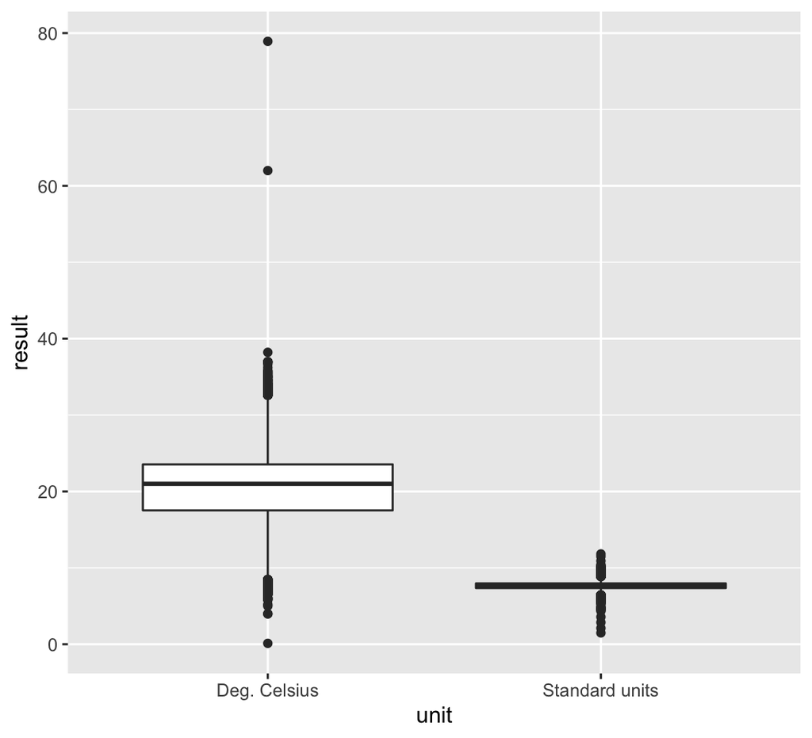

```r
ggplot(data=filtered_water,mapping=aes(x=unit,y=result)) + geom_boxplot()
```

```r
filtered_water<-filtered_water[,-c(4,7)]
filtered_water_wide<-spread(filtered_water,parameter,result) #this returns an error message because there are duplicate measurements
```

[output not shown]

[output cut: 2824 more lines]

[output not shown]

```r
dupe_check<-filtered_water[,-5]
dupes<-which(duplicated(dupe_check)) #there are about 14,000 duplicates; if I actually saw this I would wonder why this is the case. "maybe the city routinely takes two water measurements at the same time and averages them"
filtered_water<-filtered_water[-dupes,]
filtered_water_wide<-spread(filtered_water,parameter,result)
colnames(filtered_water_wide)[4]<-'pH'
colnames(filtered_water_wide)[5]<-'temperatures'
glimpse(filtered_water_wide)
```

```
#> Rows: 21,906
#> Columns: 5
#> $ siteName     <chr> "58-50-215 Sunset Valley", "58-50-2CW Pickard (58-50-230…
#> $ siteType     <fct> Well, Well, Well, Well, Well, Well, Well, Well, Well, We…
#> $ sampleTime   <dttm> 1986-07-18 00:00:00, 2010-05-12 12:40:00, 2010-05-26 14…
#> $ pH           <dbl> 8.10, 7.18, 7.14, 7.28, 7.22, 6.65, 7.00, 7.02, 7.08, 7.…
#> $ temperatures <dbl> NA, NA, 22.77, 22.77, 22.72, 23.37, 22.06, 22.92, 22.80,…
```